# Sensoriamento Remoto Aplicado II: Mudanças e Trajetórias

Prof. Dr. Luiz Diego Vidal Santos

## Visão Geral da Aula

### Tópicos

- 1 Detecção de mudanças na paisagem
- 2 Métodos de comparação temporal
- 3 Trajetórias de transformação
- 4 MapBiomas: transições e séries históricas
- 5 Interpretação socioambiental das mudanças
- 6 Limitações e cuidados

**Objetivo da Aula**

Compreender os métodos de **comparação temporal** em sensoriamento remoto, interpretar **trajetórias de transformação** da paisagem e discutir suas **dimensões socioambientais**, utilizando séries históricas de imagens e dados do MapBiomas.

# DETECÇÃO DE MUDANÇAS

## A paisagem muda: como detectar?

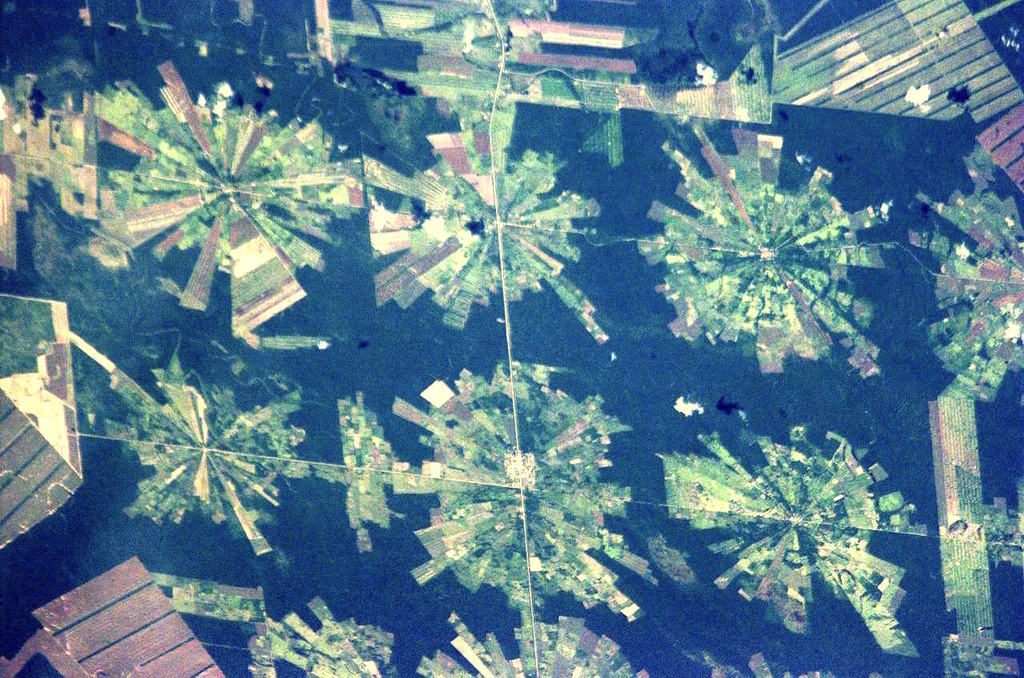

### Mudança na paisagem

A paisagem é **dinâmica** - seus padrões se transformam no tempo por:

- **Processos naturais:** sucessão ecológica, erosão, seca, inundação
- **Processos antrópicos:** desmatamento, urbanização, agricultura, reflorestamento
- **Eventos abruptos:** fogo, deslizamento, enchente
- **Mudanças graduais:** degradação, invasão biológica, desertificação

### Por que detectar mudanças?

1. **Diagnóstico** - o que mudou e onde?
2. **Velocidade** - quão rápido está mudando?
3. **Direção** - para qual estado a paisagem está evoluindo?
4. **Causa provável** - processo natural ou antrópico?
5. **Gestão** - as mudanças são desejáveis? Reversíveis?

**Tipos de mudança**

| Tipo | Exemplo | Velocidade |
| --- | --- | --- |
| **Conversão** | Floresta → pastagem | Rápida |
| **Modificação** | Floresta densa → floresta degradada | Gradual |
| **Recuperação** | Pastagem → regeneração | Gradual |
| **Cíclica** | Vegetação caducifólia (seca/chuva) | Sazonal |
| **Abrupta** | Incêndio, deslizamento | Instantânea |

### Na análise da paisagem

> *“Compreender a paisagem exige leitura do presente E do passado. Padrões atuais são resultado de trajetórias históricas de transformação.”* (adaptado de Turner & Gardner, 2015)

A detecção de mudanças complementa a análise estática (Aula 16) com a **dimensão temporal**.

## Regimes de distúrbio e dinâmica da paisagem

### Distúrbios como forçantes de heterogeneidade

Além das forças motrizes socioeconômicas, a paisagem é modulada por **regimes de distúrbio** (Turner, 2010), definidos pelo padrão temporal e espacial de eventos que removem biomassa ou redefinem condições abióticas.

Um regime de distúrbio é caracterizado por:

- **Frequência** - intervalo médio entre eventos
- **Intensidade** - magnitude do impacto
- **Extensão** - área afetada por evento
- **Sazonalidade** - época preferencial de ocorrência

### Categorias relevantes no Brasil

| Distúrbio | Exemplo | Efeito na paisagem |
| --- | --- | --- |
| **Fogo** | Queimadas no Cerrado/Amazônia | Seleção de espécies rebrotantes, conversão de fisionomias |
| **Eventos climáticos extremos** | Seca 2015-16 na Amazônia | Mortalidade seletiva de árvores, deslizamentos |
| **Perturbações antrópicas agudas** | Barragens, mineração, rodovias | Fragmentação abrupta, redefinição de drenagem |

**Equilíbrio vs. não-equilíbrio**

A interação entre regime de distúrbio e extensão da paisagem determina o comportamento do sistema:

- **Equilíbrio:** distúrbios frequentes mas pequenos em relação à paisagem → proporção de cada estágio sucessional permanece estável
- **Não-equilíbrio:** distúrbios raros mas extensos → alteram simultaneamente grande parte da paisagem (ex.: incêndios catastróficos)

### Implicação para detecção de mudanças

A detecção de mudanças por sensoriamento remoto deve distinguir:

1. Mudanças **dirigidas por distúrbio natural** (fogo, enchente) → recuperação potencial
2. Mudanças **dirigidas por conversão antrópica** (desmatamento) → tendência irreversível sem intervenção
3. Mudanças **interativas** (fogo em borda de fragmento desmatado) → retroalimentação positiva

> *“Distúrbios não são desvios do normal - são parte integral da dinâmica da paisagem.”* - Turner (2010, adaptado)

# MÉTODOS DE COMPARAÇÃO TEMPORAL

## Abordagens para detectar mudanças

### Método 1: Comparação visual (qualitativa)

- Comparar imagens de **datas diferentes** lado a lado
- Usar a **mesma composição** e escala de cores
- Identificar visualmente áreas com diferença de tonalidade

**Vantagem:** simples, intuitivo, não exige processamento **Limitação:** subjetiva, difícil de quantificar

### Método 2: Diferença de índices (quantitativa)

ΔNDVI = NDVI_t2 − NDVI_t1

- Valores **positivos** → aumento de vegetação (recuperação)
- Valores **negativos** → perda de vegetação (degradação)
- Valores **próximos de zero** → sem mudança significativa

**Vantagem:** quantitativa, espacialmente explícita **Limitação:** sensível à sazonalidade e condições atmosféricas

### Método 3: Pós-classificação

- Classificar imagens de **duas datas** independentemente
- Cruzar os mapas → **matriz de transição**
- Identificar tipo e quantidade de mudança por classe

| Classe t₁ | Classe t₂ | Transição |
| --- | --- | --- |
| Floresta | Pastagem | Desmatamento |
| Pastagem | Solo exposto | Degradação |
| Solo exposto | Vegetação | Regeneração |
| Agricultura | Urbanização | Expansão urbana |

**Vantagem:** identifica o tipo de mudança (de quê → para quê) **Limitação:** erros das duas classificações se acumulam

**Para a disciplina:** usaremos a abordagem de **pós-classificação via MapBiomas**, que oferece mapas anuais prontos e matrizes de transição.

# TRAJETÓRIAS DE TRANSFORMAÇÃO

## Leitura temporal da paisagem

### O conceito de trajetória

Uma **trajetória** é a sequência de estados que um pixel (ou unidade da paisagem) percorre ao longo do tempo:

```
1985: Floresta
1990: Floresta
1995: Floresta → Pastagem    ← CONVERSÃO
2000: Pastagem
2005: Pastagem → Solo exposto ← DEGRADAÇÃO
2010: Solo exposto
2015: Solo exposto → Regeneração ← RECUPERAÇÃO
2020: Vegetação secundária
```

### Tipos de trajetória

1. **Estável** - sem mudança por todo o período (ex: floresta conservada)
2. **Conversão única** - uma mudança definitiva (ex: desmatamento)
3. **Múltiplas conversões** - mudanças sequenciais (ex: floresta → pastagem → eucalipto)
4. **Oscilante** - alternância entre estados (ex: pousio agrícola)
5. **Recuperação** - retorno a estado anterior (ex: regeneração)

**MapBiomas: trajetórias 1985-2023**

O MapBiomas classifica a cobertura do Brasil a cada ano desde 1985, permitindo:

- **Mapas de uso/cobertura anuais** - 38+ anos
- **Mapas de transição** - de quê para quê entre dois anos
- **Estatísticas por município/bioma** - área de cada classe ao longo do tempo
- **Dashboard** - gráficos interativos de mudança

### Exemplo: Caatinga (dados MapBiomas)

| Período | Floresta (%) | Pastagem (%) | Agricultura (%) |
| --- | --- | --- | --- |
| 1985 | 63% | 25% | 3% |
| 2000 | 55% | 32% | 5% |
| 2010 | 48% | 36% | 8% |
| 2023 | 42% | 38% | 12% |

> Perda de ~21 pontos percentuais de cobertura nativa em 38 anos.

## Matriz de transição

### Modelo de matriz

A **matriz de transição** mostra a conversão entre classes em dois momentos:

| t₁ t₂ | Floresta | Pastagem | Agricultura | Solo exposto | Total t₁ |
| --- | --- | --- | --- | --- | --- |
| **Floresta** | **800** | 120 | 30 | 50 | 1000 |
| **Pastagem** | 20 | **550** | 80 | 50 | 700 |
| **Agricultura** | 5 | 15 | **170** | 10 | 200 |
| **Solo exposto** | 10 | 20 | 10 | **60** | 100 |
| **Total t₂** | 835 | 705 | 290 | 170 | **2000** |

**Leitura:** A diagonal (negrito) = **estabilidade** (sem mudança). Fora da diagonal = **transição**. Exemplo: 120 ha de floresta → pastagem; 20 ha de pastagem → floresta (regeneração). **Ganho líquido de pastagem** = 705 - 700 = +5 ha. **Perda líquida de floresta** = 1000 - 835 = -165 ha.

# INTERPRETAÇÃO SOCIOAMBIENTAL

## Da mudança à explicação

### Fatores que explicam as mudanças

| **Fator** | **Mecanismo** | **Exemplo** |
| --- | --- | --- |
| Expansão agropecuária | Conversão de vegetação nativa | Desmatamento na Caatinga |
| Políticas públicas | Crédito, regularização, proteção | PRONAF, CAR, UC |
| Infraestrutura | Abertura de estradas, irrigação | Pivôs no semiárido |
| Mercado | Preço de commodities, demanda | Soja, pecuária |
| Abandono | Êxodo rural, inviabilidade | Regeneração em encostas |
| Eventos climáticos | Seca prolongada, enchente | Perda de mata ciliar |

### Modelo DPSIR aplicado

```
Driving forces → Pressões → Estado → Impacto → Resposta
(economia)     (desmatamento) (paisagem) (biodiversidade) (política)
```

**Perguntas interpretativas**

Para cada mudança identificada, pergunte:

1. **O quê** mudou? (classe A → classe B)
2. **Onde** mudou? (localização, relevo, proximidade)
3. **Quando** mudou? (período, velocidade)
4. **Quanto** mudou? (área, proporção)
5. **Por quê** mudou? (fator provável)
6. **E daí?** (consequência para funcionalidade, serviços ecossistêmicos, população)

### Exemplo interpretativo ⚠️ *cenário didático hipotético*

> *“Entre 1990 e 2020, a área de estudo perdeu 58% da cobertura de caatinga, concentrada nas áreas de relevo suave (< 8% de declividade), sugerindo conversão seletiva para pastagem extensiva. A vegetação remanescente (12%) concentra-se em encostas íngremes e topos, formando fragmentos isolados sem corredores de conexão.”*

# LIMITAÇÕES E CUIDADOS

## O que pode dar errado?

### Limitações técnicas

| Limitação | Problema | Mitigação |
| --- | --- | --- |
| **Nuvens** | Ocultam superfície | Composição temporal (mosaico) |
| **Sazonalidade** | Vegetação caducifólia parece solo nu | Comparar mesma época do ano |
| **Resolução** | Feições menores que o pixel | Usar SR de maior resolução |
| **Classificação** | Confusão entre classes semelhantes | Validação com amostras/campo |
| **Período** | Série pode não cobrir o evento | Complementar com outras fontes |

### Armadilhas comuns

1. ❌ Comparar imagens de **estações diferentes** (chuvosa vs. seca)
2. ❌ Usar classificação sem verificar **acurácia**
3. ❌ Assumir que **toda mudança é antrópica**
4. ❌ Ignorar **erros da classificação** na interpretação
5. ❌ Extrapolar conclusões **sem dados suficientes**

**Boas práticas**

✅ Comparar **mesma estação** do ano ✅ Usar **composição temporal** (mediana, mosaico) para reduzir nuvens ✅ Verificar **consistência** entre fontes (MapBiomas vs. imagem bruta) ✅ Distinguir **mudança real** de **variação sazonal** ✅ Relacionar mudanças com **contexto** (política, economia, clima) ✅ Documentar **incertezas** e limitações na análise ✅ Triangular com **outras evidências** (campo, entrevista, dados sociais)

### O papel do analista

> *“O sensoriamento remoto mostra O QUE mudou. Cabe ao analista da paisagem interpretar POR QUÊ e COM QUE CONSEQUÊNCIAS.”*

A imagem é evidência. A interpretação é do geógrafo.

## Para a próxima aula (Aula 18)

### Atividade: produto parcial

Na Aula 18, você produzirá um **registro interpretativo de mudanças** na área de estudo:

1. Selecionar 2 datas (ex: 1990 e 2020)
2. Gerar mapas MapBiomas para ambas
3. Construir matriz de transição simplificada
4. Produzir mapa/figura comparativa
5. Escrever texto interpretativo (1-2 parágrafos)

**Leitura preparatória**

- Acessar **MapBiomas** e explorar a aba de **transições**
- Verificar dados do **município** da área de estudo
- Identificar as principais **tendências** ao longo da série

## Síntese da Aula 17

**O que vimos hoje**

1. **Detecção de mudanças** - por que e como identificar transformações na paisagem
2. **Métodos** - comparação visual, diferença de índices, pós-classificação
3. **Trajetórias** - sequência temporal de estados; estável, conversão, oscilante, recuperação
4. **Matriz de transição** - quantifica “de quê → para quê” entre dois momentos
5. **Interpretação socioambiental** - fatores DPSIR, perguntas-chave, contexto
6. **Limitações** - nuvens, sazonalidade, resolução, erros de classificação

Obrigado!

Luiz Diego Vidal Santos

Universidade Estadual de Feira de Santana (UEFS)

Análise da Paisagem - Aula 17